# TEBILI Stephanie & YEO Ditchaba

**TRAVAIL DE GROUPE**

**Projet Scoring**

**PRESENTATEURS:** TEBILI STEPHANIE & YEO DITCHABA

**OBJECTIF DE L'ETUDE:** Construire le meilleur modèle de classification pour scorer le niveau d'engagement des joueurs

**Importation des packages**

```python
%matplotlib inline

%load_ext autoreload
%autoreload 2


# data manipulation
import numpy as np
import pandas as pd

# data visualization
import sklearn.metrics as sm
import matplotlib.pyplot as plt
from sklearn import linear_model
import seaborn as sns
from IPython.display import display
import os
sns.set()

# filter warnings
import warnings
warnings.filterwarnings('ignore')
```

```
The autoreload extension is already loaded. To reload it, use:
  %reload_ext autoreload
```

**Importation des données**

```python
import os
data=pd.read_csv('C:/Ditch/DATA SCIENCE/Projet Scoring/Fichiers Projet/donnees soring de la performance joueur en ligne.txt',delimiter='\t')
data.head()
```

|  | PlayerID | Age | Gender | Location | GameGenre | PlayTimeHours | InGamePurchases | GameDifficulty | SessionsPerWeek | AvgSessionDurationMinutes | PlayerLevel | AchievementsUnlocked | EngagementLevel |
| --- | --- | --- | --- | --- | --- | --- | --- | --- | --- | --- | --- | --- | --- |
| 0 | 9000 | 43.0 | Male | Other | Strategy | 16.271119 | 0 | Medium | 6.0 | 108.0 | 79.0 | 25.0 | Medium |
| 1 | 9001 | 29.0 | Female | USA | Strategy | 5.525961 | 0 | Medium | 5.0 | 144.0 | 11.0 | 10.0 | Medium |
| 2 | 9002 | 22.0 | Female | USA | Sports | 8.223755 | 0 | Easy | NaN | 142.0 | 35.0 | 41.0 | High |
| 3 | 9003 | 35.0 | Male | USA | Action | 5.265351 | 1 | Easy | 9.0 | 85.0 | 57.0 | 47.0 | Medium |
| 4 | 9004 | 33.0 | Male | Europe | Action | 15.531945 | 0 | Medium | 2.0 | 131.0 | 95.0 | 37.0 | Medium |

```python
print("Nombre de lignes de la base : ", data.shape[0])
print("Nombre de colonnes de la base : " ,data.shape[1])
```

```
Nombre de lignes de la base :  29710
Nombre de colonnes de la base :  13
```

```python
data.columns
```

```
Index(['PlayerID', 'Age', 'Gender', 'Location', 'GameGenre', 'PlayTimeHours',
       'InGamePurchases', 'GameDifficulty', 'SessionsPerWeek',
       'AvgSessionDurationMinutes', 'PlayerLevel', 'AchievementsUnlocked',
       'EngagementLevel'],
      dtype='object')
```

```python
data.dtypes,data.count()
```

```
(PlayerID                       int64
 Age                          float64
 Gender                        object
 Location                      object
 GameGenre                     object
 PlayTimeHours                float64
 InGamePurchases                int64
 GameDifficulty                object
 SessionsPerWeek              float64
 AvgSessionDurationMinutes    float64
 PlayerLevel                  float64
 AchievementsUnlocked         float64
 EngagementLevel               object
 dtype: object,
 PlayerID                     29710
 Age                          29696
 Gender                       29710
 Location                     29710
 GameGenre                    29710
 PlayTimeHours                29710
 InGamePurchases              29710
 GameDifficulty               29710
 SessionsPerWeek              29704
 AvgSessionDurationMinutes    29707
 PlayerLevel                  29706
 AchievementsUnlocked         29705
 EngagementLevel              29710
 dtype: int64)
```

```python
#Encodage de la variable cible EngagementLevel de type catégoriel en numerique

data['EngagementLevel'] = data['EngagementLevel'].map({'Medium': 0, 'High': 1})
```

```python
data.head()
```

|  | PlayerID | Age | Gender | Location | GameGenre | PlayTimeHours | InGamePurchases | GameDifficulty | SessionsPerWeek | AvgSessionDurationMinutes | PlayerLevel | AchievementsUnlocked | EngagementLevel |
| --- | --- | --- | --- | --- | --- | --- | --- | --- | --- | --- | --- | --- | --- |
| 0 | 9000 | 43.0 | Male | Other | Strategy | 16.271119 | 0 | Medium | 6.0 | 108.0 | 79.0 | 25.0 | 0 |
| 1 | 9001 | 29.0 | Female | USA | Strategy | 5.525961 | 0 | Medium | 5.0 | 144.0 | 11.0 | 10.0 | 0 |
| 2 | 9002 | 22.0 | Female | USA | Sports | 8.223755 | 0 | Easy | NaN | 142.0 | 35.0 | 41.0 | 1 |
| 3 | 9003 | 35.0 | Male | USA | Action | 5.265351 | 1 | Easy | 9.0 | 85.0 | 57.0 | 47.0 | 0 |
| 4 | 9004 | 33.0 | Male | Europe | Action | 15.531945 | 0 | Medium | 2.0 | 131.0 | 95.0 | 37.0 | 0 |

```python
#Nombre de données manquantes par colonne
data.isnull().sum()
```

```
PlayerID                      0
Age                          14
Gender                        0
Location                      0
GameGenre                     0
PlayTimeHours                 0
InGamePurchases               0
GameDifficulty                0
SessionsPerWeek               6
AvgSessionDurationMinutes     3
PlayerLevel                   4
AchievementsUnlocked          5
EngagementLevel               0
dtype: int64
```

```python
#Imputer les valeur manquantes

def Imput_ValeurManquate ( Data, columns_Num, Imput_Num= "median") :
    for col in columns_Num :
        if Imput_Num == "median" :
            Change = np.median(Data[col].dropna())
        else:
            Change = int(Imput_Num)
        Data[col] = Data[col].fillna(Change)

    return(Data)
```

```python
data_without_na = Imput_ValeurManquate(data, ["Age","SessionsPerWeek","AvgSessionDurationMinutes","PlayerLevel","AchievementsUnlocked"])
assert list(data_without_na.isnull().sum() ) == [0]*data_without_na .shape[1]
```

```python
data_without_na.describe()
```

|  | PlayerID | Age | PlayTimeHours | InGamePurchases | SessionsPerWeek | AvgSessionDurationMinutes | PlayerLevel | AchievementsUnlocked | EngagementLevel |
| --- | --- | --- | --- | --- | --- | --- | --- | --- | --- |
| count | 29710.000000 | 29710.000000 | 29710.000000 | 29710.000000 | 29710.000000 | 29710.000000 | 29710.000000 | 29710.000000 | 29710.000000 |
| mean | 28989.980310 | 32.026759 | 11.996375 | 0.202087 | 11.188657 | 104.490172 | 50.889667 | 25.174150 | 0.347896 |
| std | 11560.994353 | 10.047790 | 6.924218 | 0.401563 | 5.012555 | 45.294409 | 28.599737 | 14.454653 | 0.476311 |
| min | 9000.000000 | 15.000000 | 0.000115 | 0.000000 | 0.000000 | 10.000000 | 1.000000 | 0.000000 | 0.000000 |
| 25% | 19001.250000 | 23.000000 | 6.028191 | 0.000000 | 7.000000 | 67.000000 | 26.000000 | 13.000000 | 0.000000 |
| 50% | 28993.500000 | 32.000000 | 11.991068 | 0.000000 | 11.000000 | 107.000000 | 51.000000 | 26.000000 | 0.000000 |
| 75% | 39003.500000 | 41.000000 | 17.942027 | 0.000000 | 16.000000 | 143.000000 | 76.000000 | 38.000000 | 1.000000 |
| max | 49033.000000 | 49.000000 | 23.999592 | 1.000000 | 19.000000 | 179.000000 | 99.000000 | 49.000000 | 1.000000 |

```python
#cible et choix colonnes
def DataModel(features , Data , label) :
    Train = Data[features]
    if label in Data.columns :
        label = Data[label]
        return Train, label

    return Train
```

**Modèle initial**

```python
#Train
feature = ['PlayTimeHours', 'InGamePurchases', 'AchievementsUnlocked','SessionsPerWeek' ]
Data= data_without_na
Label = "EngagementLevel"
X, y = DataModel (feature, Data, Label)
X.head()
```

|  | PlayTimeHours | InGamePurchases | AchievementsUnlocked | SessionsPerWeek |
| --- | --- | --- | --- | --- |
| 0 | 16.271119 | 0 | 25.0 | 6.0 |
| 1 | 5.525961 | 0 | 10.0 | 5.0 |
| 2 | 8.223755 | 0 | 41.0 | 11.0 |
| 3 | 5.265351 | 1 | 47.0 | 9.0 |
| 4 | 15.531945 | 0 | 37.0 | 2.0 |

```python
y
```

```
0        0
1        0
2        1
3        0
4        0
        ..
29705    0
29706    1
29707    1
29708    0
29709    0
Name: EngagementLevel, Length: 29710, dtype: int64
```

**Modélisation**

**Regression Logistique**

```python
from sklearn.model_selection import train_test_split
X_train, X_test,y_train, y_test = train_test_split(X, y, test_size=0.33, random_state=42)

#construction du model
Reg_Log = linear_model.LogisticRegression(random_state=42)

#Apprentissage du model
Reg_Log.fit(X_train, y_train)

#Prediction du model
ypred = Reg_Log.predict(X_test)
```

```python
## Score
from sklearn import metrics
# Get an initial score
score = Reg_Log.score(X_train, y_train)
print("In-Train score: {:0.2%}".format(score))

# Score test
score =Reg_Log.score(X_test, y_test)
print("In-Test score: {:0.2%}".format(score))

# Log Loss
log_loss = metrics.accuracy_score(y_test , ypred)
print("Log Loss {:0.2}".format(log_loss) )
```

```
In-Train score: 71.27%
In-Test score: 71.67%
Log Loss 0.72
```

```
    Model Scores  Reg_Log1
0       Accuracy  0.716675
1      Precision  0.600648
2         Recall  0.545160
3       F1 Score  0.571561
4        ROC AUC  0.775523
5  Cross Entropy  0.534716
6    Cohen Kappa  0.360660
```

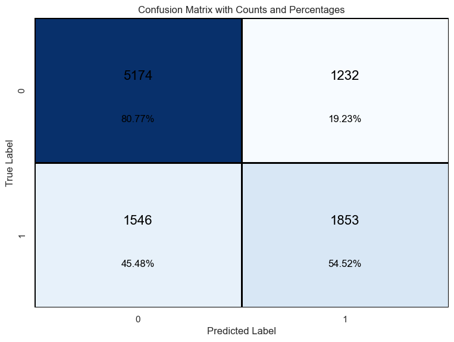

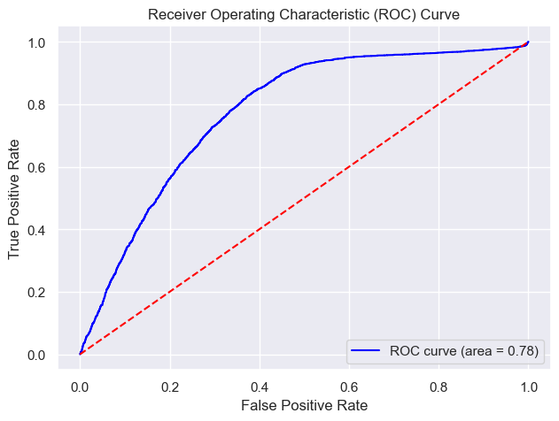

```
Comparison with other models:
```

```
{'accuracy': 0.7166751657317695,
 'precision': 0.6006482982171799,
 'recall': 0.5451603412768461,
 'f1_score': 0.5715607649599014,
 'roc_auc': 0.7755230850160058,
 'cross_entropy': 0.5347161657051727,
 'cohen_kappa': 0.36066040133988075}
```

```python
#Model Reg Logistic
import sys
sys.path.append(r'C:/Ditch/DATA SCIENCE/Projet Scoring/module evaluation/module_evaluation')

from module_evaluation import evaluate_model


y_test, y_pred, y_prob = My_model(X, y, size=0.33)
evaluate_model(y_test, y_pred, y_prob, "Reg_Log1")
```

Le modèle initial nous donne un accuracy de 0.71 et une précision de 0.60. Nous allons essayer d'améliorer les performances du modèle initial

**Influence des variables et amélioration du Score**

**Distribution de PlayerLevel par rapport à la variable cible**

```python
from matplotlib import style
style.use('fivethirtyeight')
%matplotlib inline
%pylab inline



def PlotHist(X1, X2, feature) :
    # plot histograms
    x1 = np.array(X1[feature].dropna())
    x2 = np.array(X2[feature].dropna())
    plt.hist([x1, x2], label=["High", "Medium"], bins=18, color=['b', 'r'])

    # add title and legend to the plot
    plt.title("Distribution des Niveaux des Joueurs par %s" %feature )
    plt.legend(loc="upper left")
    plt.legend()
    plt.show()
```

```
%pylab is deprecated, use %matplotlib inline and import the required libraries.
```

**Distribution de PlayerLevel par rapport à la variable cible**

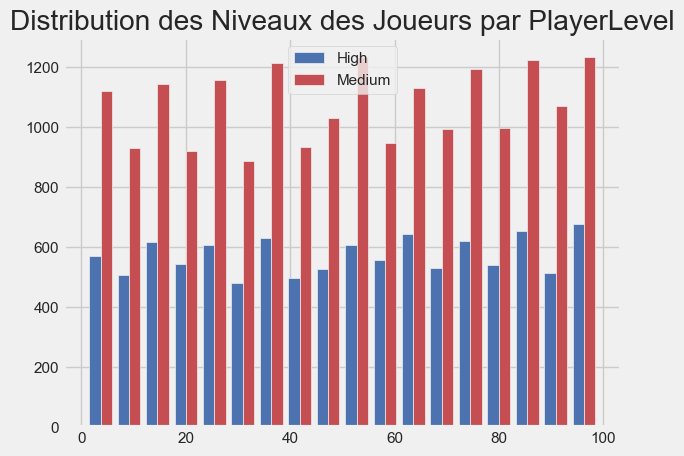

```python
# separate High and Medium : use to mask
mask_EngagementLevel = data.EngagementLevel == 1
High= data[mask_EngagementLevel]
High.dropna()
Medium= data[~mask_EngagementLevel]
Medium.dropna()

#Mon_plot
PlotHist(High, Medium, 'PlayerLevel')
```

```python
# Ajout de PlayerLevel comme caractéristique
feature = ['PlayTimeHours', 'InGamePurchases', 'AchievementsUnlocked','SessionsPerWeek' , 'PlayerLevel']
X, y = DataModel(feature, Data, Label)
```

```python
X =data[feature]
X.head()
```

|  | PlayTimeHours | InGamePurchases | AchievementsUnlocked | SessionsPerWeek | PlayerLevel |
| --- | --- | --- | --- | --- | --- |
| 0 | 16.271119 | 0 | 25.0 | 6.0 | 79.0 |
| 1 | 5.525961 | 0 | 10.0 | 5.0 | 11.0 |
| 2 | 8.223755 | 0 | 41.0 | 11.0 | 35.0 |
| 3 | 5.265351 | 1 | 47.0 | 9.0 | 57.0 |
| 4 | 15.531945 | 0 | 37.0 | 2.0 | 95.0 |

[output not shown]

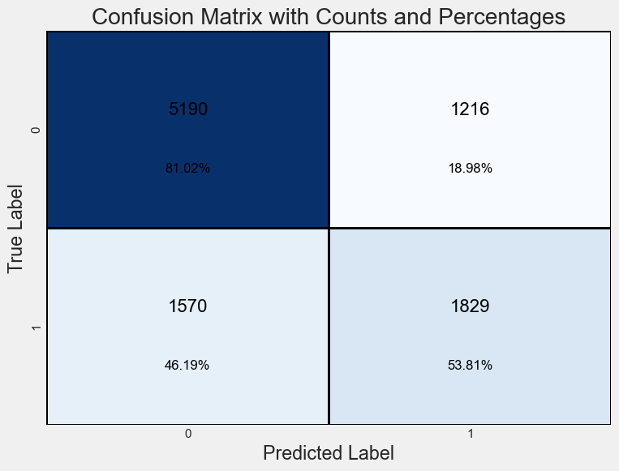

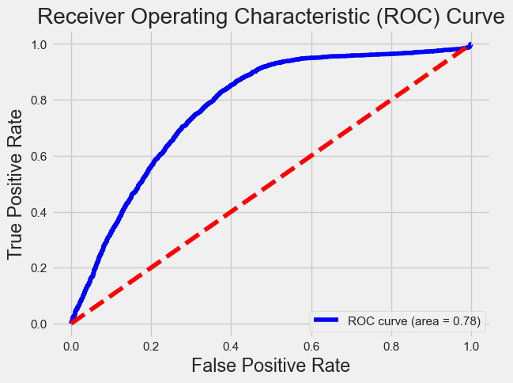

```
Comparison with other models:
```

```
{'accuracy': 0.715859255481897,
 'precision': 0.6006568144499179,
 'recall': 0.5380994410120624,
 'f1_score': 0.5676598386095593,
 'roc_auc': 0.7757491804213779,
 'cross_entropy': 0.5345863776977643,
 'cohen_kappa': 0.35700392928927016}
```

```python
#Mymodel2 et Evaluation du Modele2
y_test, y_pred, y_prob = My_model(X,y, size=0.33)

# Evaluation des performances du Modele2
evaluate_model(y_test, y_pred, y_prob, "Reg_Log2")
```

On constate une légère amélioration de la précision même si elle n'est pas significative.

**Distribution de AvgSessionDurationMinutes par rapport à la variable cible**

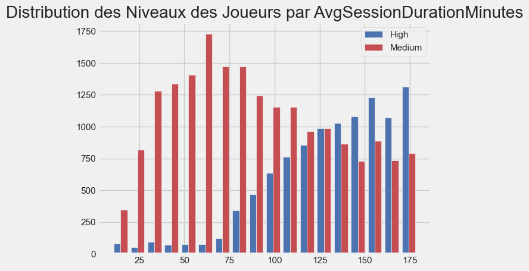

```python
PlotHist(High, Medium, 'AvgSessionDurationMinutes')
```

On constate que les joueurs ayant une durée moyenne inférieure à 125 minutes ont majoritairement un niveau **Medium** tandis que ceux ayant une durée moyene supérieurse à 125 minutes ont majoritairement un niveau **High**

```python
# Créer une nouvelle variable binaire pour AvgDurationMinutes
data['DurationClass'] = np.where(data['AvgSessionDurationMinutes'] < 125, 0, 1)  # 0 pour < 125, 1 pour >= 125
```

```python
# Mettre à jour les caractéristiques
feature = ['PlayTimeHours', 'InGamePurchases', 'AchievementsUnlocked', 'SessionsPerWeek', 'PlayerLevel', 'DurationClass']
X = data[feature]
X.head()
```

|  | PlayTimeHours | InGamePurchases | AchievementsUnlocked | SessionsPerWeek | PlayerLevel | DurationClass |
| --- | --- | --- | --- | --- | --- | --- |
| 0 | 16.271119 | 0 | 25.0 | 6.0 | 79.0 | 0 |
| 1 | 5.525961 | 0 | 10.0 | 5.0 | 11.0 | 1 |
| 2 | 8.223755 | 0 | 41.0 | 11.0 | 35.0 | 1 |
| 3 | 5.265351 | 1 | 47.0 | 9.0 | 57.0 | 0 |
| 4 | 15.531945 | 0 | 37.0 | 2.0 | 95.0 | 1 |

[output not shown]

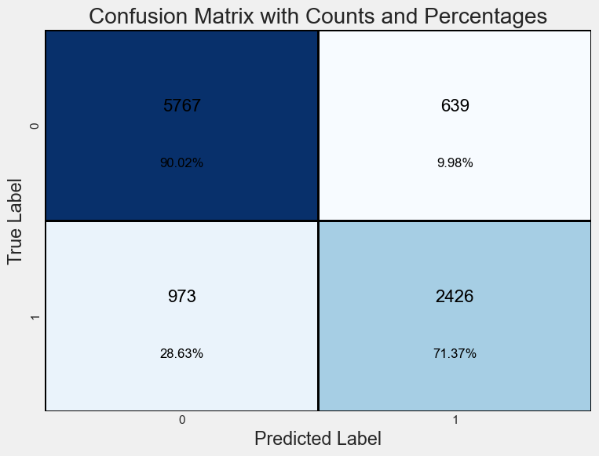

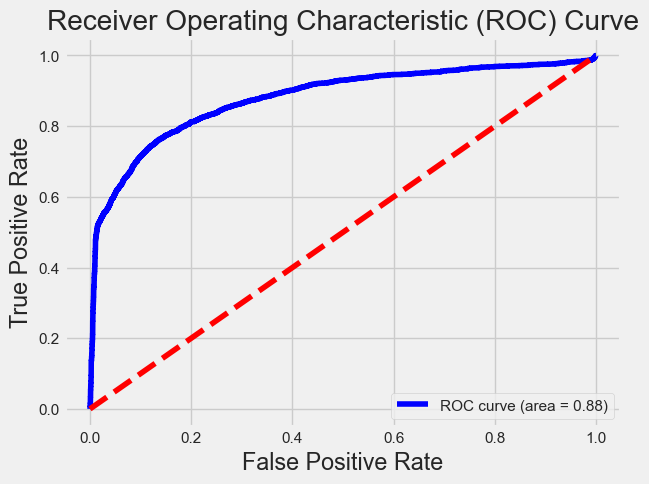

```
Comparison with other models:
```

```
{'accuracy': 0.8355940846506884,
 'precision': 0.7915171288743883,
 'recall': 0.7137393350985584,
 'f1_score': 0.7506188118811882,
 'roc_auc': 0.8791025661162578,
 'cross_entropy': 0.41365338799378043,
 'cohen_kappa': 0.6284836867546626}
```

```python
#Mymodele3 et Evaluation du Modele3
y_test, y_pred, y_prob = My_model(X,y, size=0.33)

# Evaluate performance
evaluate_model(y_test, y_pred, y_prob, "Reg_Log3")
```

**Distribution de Age par rapport à la variable cible**

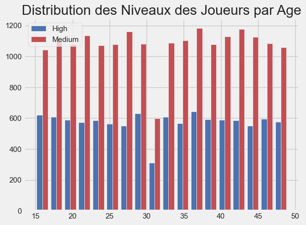

```python
PlotHist(High, Medium, 'Age')
```

```python
# Ajout de Age comme caractéristique
feature = ['PlayTimeHours', 'InGamePurchases', 'AchievementsUnlocked', 'SessionsPerWeek', 'PlayerLevel', 'DurationClass', 'Age']
X = data[feature]
X.head()
```

|  | PlayTimeHours | InGamePurchases | AchievementsUnlocked | SessionsPerWeek | PlayerLevel | DurationClass | Age |
| --- | --- | --- | --- | --- | --- | --- | --- |
| 0 | 16.271119 | 0 | 25.0 | 6.0 | 79.0 | 0 | 43.0 |
| 1 | 5.525961 | 0 | 10.0 | 5.0 | 11.0 | 1 | 29.0 |
| 2 | 8.223755 | 0 | 41.0 | 11.0 | 35.0 | 1 | 22.0 |
| 3 | 5.265351 | 1 | 47.0 | 9.0 | 57.0 | 0 | 35.0 |
| 4 | 15.531945 | 0 | 37.0 | 2.0 | 95.0 | 1 | 33.0 |

[output not shown]

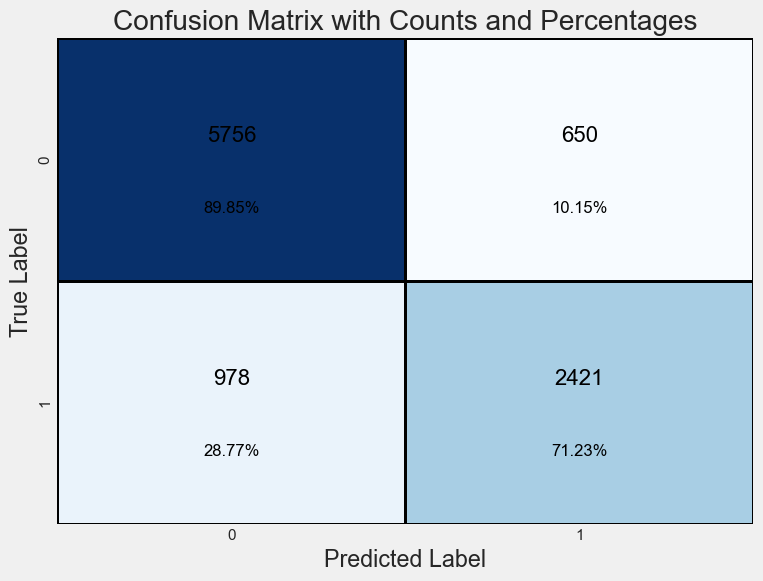

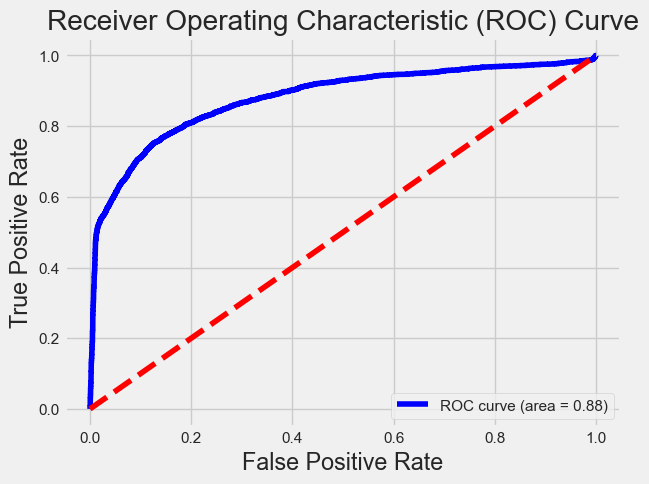

```
Comparison with other models:
```

```
{'accuracy': 0.8339622641509434,
 'precision': 0.7883425594268968,
 'recall': 0.7122683142100618,
 'f1_score': 0.7483771251931994,
 'roc_auc': 0.8791437620493511,
 'cross_entropy': 0.4135255029320369,
 'cohen_kappa': 0.624955229693406}
```

```python
#Mymodele4 et Evaluation du Modele4
y_test, y_pred, y_prob = My_model(X,y, size=0.33)

# Evaluate performance
evaluate_model(y_test, y_pred, y_prob, "Reg_Log4")
```